# Decision Tree Oktober 2024

Kode ringkas dan jawaban soal (a)–(d): Fraud Detection

2026-10-07

Simpan file di working directory R dengan nama aslinya, `data_soal 1_ Fraud Detection.csv`, agar kode baca data di bawah langsung jalan.

Data soal Oktober 2024 (CSV) · 3.2 MB

**Cara menjalankan:** letakkan Rmd dan

```
data_soal
1_ Fraud Detection.csv
```

dalam folder yang sama, buka Rmd di RStudio, lalu klik **Knit**. Bagian 1 membuat model latihan. Bagian 2 menjawab pertanyaan berdasarkan **pohon pada PPT**.

**Angka pada gambar sudah dibulatkan.** Jawaban numerik berdasarkan gambar merupakan pendekatan. Jangan menyamakan hasil pelatihan ulang atau hasil penerapan aturan pada seluruh CSV dengan metrik pohon pada sampel undersampling asli.

# 1. Kode minimum untuk membuat decision tree

## 1.1. Library dan data

Instalasi cukup sekali melalui Console jika paket belum tersedia.

```r
install.packages(c("rpart", "rpart.plot", "caret", "rmarkdown"))
```

```r
library(rpart)
library(rpart.plot)
library(caret)
```

```r
data <- read.csv("data_soal 1_ Fraud Detection.csv",
                  stringsAsFactors = FALSE)
data <- data[, c("VehicleCat", "MonthClaimed", "Month", "Age",
                 "Make", "DriverRating", "FraudFound_P")]

data$FraudFound_P <- factor(data$FraudFound_P, levels = c(0, 1),
                            labels = c("NonFraud", "Fraud"))
data[c("VehicleCat", "MonthClaimed", "Month", "Make")] <-
  lapply(data[c("VehicleCat", "MonthClaimed", "Month", "Make")], factor)

table(data$FraudFound_P)
```

```
##
## NonFraud    Fraud
##    14208      892
```

```r
prop.table(table(data$FraudFound_P))
```

```
##
##   NonFraud      Fraud
## 0.94092715 0.05907285
```

**Target:** `0 = NonFraud` dan `1 = Fraud`. Data memiliki **15.100 baris**, yaitu **14.208 NonFraud (94,09%)** dan **892 Fraud (5,91%)**, sama dengan tabel soal. Kolom yang dipakai tidak memiliki nilai kosong.

Agar kode ringkas dan relevan dengan gambar, model latihan memakai **enam prediktor yang muncul pada pohon soal**: `VehicleCat`, `MonthClaimed`, `Month`, `Age`, `Make`, dan `DriverRating`. Kolom identitas seperti `PolicyNumber` tidak digunakan. `Age` dan `DriverRating` tetap numerik agar dapat dibagi berdasarkan batas seperti pada gambar.

## 1.2. Split dan undersampling

```r
set.seed(123)
id <- createDataPartition(data$FraudFound_P, p = 0.7, list = FALSE)
train <- data[id, ]
test <- data[-id, ]
```

```r
set.seed(123)
train_balance <- downSample(train[, 1:6], train$FraudFound_P,
                            yname = "FraudFound_P")
table(train_balance$FraudFound_P)
```

```
##
## NonFraud    Fraud
##      625      625
```

Training 70% dipakai untuk melatih model; testing 30% untuk evaluasi. `downSample()` mengambil sebagian NonFraud secara acak sampai jumlahnya sama dengan Fraud. **Undersampling hanya pada training setelah split**; testing tetap mencerminkan distribusi kelas asal.

Seed 123 dan pembagian 70:30 merupakan pilihan latihan. PPT tidak menyediakan seed, anggota sampel undersampling, ataupun seluruh parameter model asli, sehingga hasil latihan tidak harus identik dengan pohon soal.

## 1.3. Model dan gambar pohon

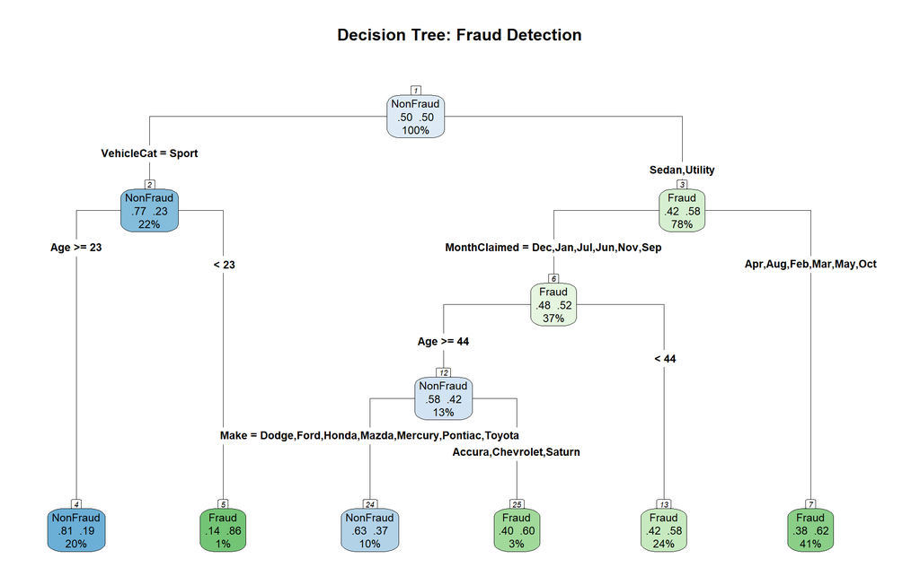

```r
model <- rpart(FraudFound_P ~ ., data = train_balance, method = "class")
rpart.plot(model, type = 4, extra = 104, nn = TRUE,
           fallen.leaves = TRUE, main = "Decision Tree: Fraud Detection")
```

`method = "class"` membuat pohon klasifikasi. Parameter lain memakai default agar kode mudah dihafalkan. `nn = TRUE` menampilkan nomor node. Kotak node berisi kelas prediksi, proporsi **NonFraud lalu Fraud**, dan persentase training seimbang yang masuk ke node.

## 1.4. Evaluasi pada testing

```r
pred <- predict(model, test, type = "class")
cm <- confusionMatrix(pred, test$FraudFound_P, positive = "Fraud",
                       mode = "everything")
cm
```

```
## Confusion Matrix and Statistics
##
##           Reference
## Prediction NonFraud Fraud
##   NonFraud     1896    37
##   Fraud        2366   230
##
##                Accuracy : 0.4694
##                  95% CI : (0.4548, 0.4841)
##     No Information Rate : 0.941
##     P-Value [Acc > NIR] : 1
##
##                   Kappa : 0.0602
##
##  Mcnemar's Test P-Value : <2e-16
##
##             Sensitivity : 0.86142
##             Specificity : 0.44486
##          Pos Pred Value : 0.08860
##          Neg Pred Value : 0.98086
##               Precision : 0.08860
##                  Recall : 0.86142
##                      F1 : 0.16067
##              Prevalence : 0.05895
##          Detection Rate : 0.05078
##    Detection Prevalence : 0.57319
##       Balanced Accuracy : 0.65314
##
##        'Positive' Class : Fraud
##
```

Ambil tiga metrik yang ditanyakan soal dengan kode singkat:

```r
100 * cm$overall["Accuracy"]
```

```
## Accuracy
## 46.94193
```

```r
100 * cm$byClass["Sensitivity"]
```

```
## Sensitivity
##    86.14232
```

```r
100 * (1 - cm$byClass["Specificity"])
```

```
## Specificity
##    55.51384
```

Ketiga baris berturut-turut menampilkan **akurasi keseluruhan**, **recall fraud**, dan **false positive rate**, dalam persen. Ini adalah evaluasi **model latihan pada testing**, sedangkan jawaban bagian 2 merujuk pada gambar soal.

# 2. Jawaban langsung berdasarkan gambar soal

## (a) Ciri klaim yang patut dicurigai fraud (7 poin)

**Faktor yang dipakai pohon:** kategori kendaraan, bulan pengajuan klaim, bulan kejadian, usia, merek kendaraan, dan rating pengemudi. `VehicleCat` menjadi pemisah pertama. `MonthClaimed` adalah bulan pengajuan klaim, sedangkan `Month` adalah bulan kejadian; keduanya jangan tertukar.

Klaim diprediksi **Fraud** apabila memenuhi **salah satu dari empat jalur** menuju daun berlabel 1. Semua syarat dalam satu baris harus dipenuhi bersama.

| Daun | Seluruh syarat menuju prediksi Fraud | Proporsi Fraud pada daun |
| --- | --- | --- |
| 13 | `VehicleCat` bukan Sport; `MonthClaimed` termasuk **Dec, Jul, Nov**; `Month` termasuk **Feb, Mar, Apr, May, Sep** | 92% |
| 15 | `VehicleCat` bukan Sport; `MonthClaimed` **bukan Dec, Jul, Nov**; `Age < 42` | 66% |
| 29 | `VehicleCat` bukan Sport; `Age >= 42`; `MonthClaimed` termasuk **Jan, Mar, Apr, Aug** | 62% |
| 115 | `VehicleCat` bukan Sport; `Age >= 42`; `MonthClaimed` termasuk **Feb, Jun, May, Oct, Sep**; `Make` **bukan Chevrolet, Ford, Pontiac, Toyota**; `DriverRating < 3.5` | 70% |

**Interpretasi:** keempat kelompok di atas patut diprioritaskan untuk pemeriksaan fraud. Daun 13 mempunyai proporsi fraud tertinggi, tetapi hanya mencakup sekitar 1% sampel. Daun 15 mencakup sekitar 36% sampel sehingga menampung kelompok dugaan fraud yang jauh lebih besar.

Pada data, `DriverRating` bernilai 1–4. Dengan demikian, `DriverRating < 3.5` berarti rating 1, 2, atau 3. Kelompok bukan Sport pada CSV adalah Sedan dan Utility.

**Baca sampai daun.** Label pada node internal belum menjadi keputusan akhir. Misalnya, bukan Sport tidak otomatis berarti Fraud: beberapa jalur lanjutannya tetap berakhir pada NonFraud. Sport diprediksi NonFraud pada pohon, tetapi daun itu masih mengandung sekitar 22% Fraud dalam sampel seimbang.

## Tabel daun untuk menghitung bagian (b)–(d)

Gunakan **daun terminal saja**. Memasukkan node internal akan menghitung observasi yang sama lebih dari sekali.

| Daun | Prediksi | Bobot: bagian seluruh sampel | Proporsi NonFraud pada daun | Proporsi Fraud pada daun |
| --- | --- | --- | --- | --- |
| 2 | NonFraud | 21% | 0,78 | 0,22 |
| 12 | NonFraud | 16% | 0,55 | 0,45 |
| 13 | Fraud | 1% | 0,08 | 0,92 |
| 56 | NonFraud | 9% | 0,61 | 0,39 |
| 114 | NonFraud | 1% | 0,68 | 0,32 |
| 115 | Fraud | 4% | 0,30 | 0,70 |
| 29 | Fraud | 11% | 0,38 | 0,62 |
| 15 | Fraud | 36% | 0,34 | 0,66 |

Persentase daun yang tercetak berjumlah **99%**, sedangkan root adalah 100%. Ini merupakan akibat pembulatan tampilan. Perhitungan berikut memakai bobot daun dan proporsi kelas di root **langsung seperti pada soal**, sehingga semuanya harus dibaca sebagai **pendekatan**, bukan angka eksak dari hitungan observasi.

## (b) Akurasi keseluruhan model (4 poin)

Akurasi adalah bagian seluruh observasi yang diprediksi benar. Pada daun NonFraud, ambil proporsi NonFraud; pada daun Fraud, ambil proporsi Fraud. Masing-masing dikalikan dengan bobot daunnya.

$$\begin{aligned}
\text{Accuracy} \approx{}&
0{,}21(0{,}78)+0{,}16(0{,}55)+0{,}01(0{,}92)\\
&+0{,}09(0{,}61)+0{,}01(0{,}68)+0{,}04(0{,}70)\\
&+0{,}11(0{,}62)+0{,}36(0{,}66)\\
={}&0{,}6565.
\end{aligned}$$

```r
# Bobot daun dalam persen; hasil juga langsung dalam persen
akurasi_soal <- sum(c(21*0.78, 16*0.55, 1*0.92, 9*0.61,
                      1*0.68, 4*0.70, 11*0.62, 36*0.66))
akurasi_soal
```

```
## [1] 65.65
```

**Jawaban: akurasi sekitar 65,65%, atau secara kasar 66%.** Ini merupakan akurasi pada sampel pembentuk pohon setelah undersampling, bukan otomatis akurasi testing atau akurasi pada populasi asal.

Rata-rata biasa proporsi mayoritas delapan daun tidak tepat karena ukuran tiap daun berbeda. Gunakan rata-rata berbobot menurut bagian data pada tiap daun.

## (c) Kemampuan mendeteksi klaim yang benar-benar fraud (2 poin)

Pertanyaan ini meminta **recall/sensitivity kelas Fraud**, yaitu proporsi fraud aktual yang berhasil diprediksi Fraud.

Fraud yang terdeteksi benar berada pada daun **13, 115, 29, dan 15**. Perkiraan bagiannya terhadap seluruh sampel adalah:

$$TP \approx 0{,}01(0{,}92)+0{,}04(0{,}70)
+0{,}11(0{,}62)+0{,}36(0{,}66)=0{,}3430.$$

Karena proporsi Fraud di root adalah 0,50:

$$\text{Recall Fraud} = \frac{TP}{TP+FN}
\approx \frac{0{,}3430}{0{,}50}=68{,}60\%.$$

```r
tp_soal <- sum(c(1*0.92, 4*0.70, 11*0.62, 36*0.66))
recall_soal <- tp_soal / 50 * 100
recall_soal
```

```
## [1] 68.6
```

**Jawaban: sekitar 68,60% klaim fraud berhasil dideteksi.** Penyebutnya seluruh fraud aktual, bukan seluruh prediksi Fraud. Karena itu, metrik yang diminta adalah recall, bukan precision.

## (d) Nonfraud yang salah diduga fraud (2 poin)

Pertanyaan ini meminta **false positive rate (FPR)**, yaitu bagian NonFraud aktual yang salah diprediksi Fraud.

Ambil proporsi **NonFraud pada daun yang diprediksi Fraud**, yaitu daun 13, 115, 29, dan 15:

$$FP \approx 0{,}01(0{,}08)+0{,}04(0{,}30)
+0{,}11(0{,}38)+0{,}36(0{,}34)=0{,}1770.$$

Karena proporsi NonFraud di root adalah 0,50:

$$\text{FPR} = \frac{FP}{FP+TN}
\approx \frac{0{,}1770}{0{,}50}=35{,}40\%.$$

```r
fp_soal <- sum(c(1*0.08, 4*0.30, 11*0.38, 36*0.34))
fpr_soal <- fp_soal / 50 * 100
fpr_soal
```

```
## [1] 35.4
```

**Jawaban: sekitar 35,40% klaim NonFraud salah diduga Fraud.** Dengan pendekatan ini, specificity sekitar `100% - 35,40% = 64,60%`.

**FPR berbeda dari 1 − precision.** FPR memakai seluruh NonFraud aktual sebagai penyebut. Sementara itu, 1 − precision memakai seluruh prediksi Fraud sebagai penyebut. Frasa “klaim yang ternyata bukan fraud” pada soal menunjuk kelas aktual, sehingga jawaban yang tepat adalah FPR.

### Mengapa tidak memberikan angka eksak dari CSV?

Pohon pada PPT dibentuk setelah undersampling. CSV memuat **seluruh 15.100 observasi**, tetapi tidak memuat penanda baris mana yang dipilih sebagai NonFraud dalam sampel asli. Menerapkan aturan pada seluruh CSV menghasilkan evaluasi pada distribusi yang berbeda. Melatih ulang dengan seed pilihan kita juga menghasilkan sampel berbeda.

Karena itu, jawaban di atas mengikuti informasi yang tersedia pada gambar. Jika bobot daun dinormalisasi ulang dari total 99% menjadi 100%, atau penyebut kelas dihitung ulang dari daun, pendekatannya dapat sedikit berbeda. Jangan mencampur cara normalisasi tersebut dalam satu rangkaian hitungan. Angka eksak memerlukan sampel pembentuk pohon atau confusion matrix aslinya.

# 3. Ringkasan yang perlu dihafal

| Bagian | Yang diminta | Rumus | Pendekatan dari gambar |
| --- | --- | --- | --- |
| (a) | Ciri klaim mencurigakan | Empat jalur menuju daun berlabel 1 | Daun 13, 15, 29, 115 |
| (b) | Akurasi keseluruhan | `(TP + TN) / N` | 65,65% |
| (c) | Fraud aktual yang terdeteksi | `TP / (TP + FN)` | 68,60% |
| (d) | NonFraud aktual yang salah ditandai | `FP / (FP + TN)` | 35,40% |

**Pola kode utama:** `read.csv()` → `factor()` → `createDataPartition()` → `downSample()` → `rpart()` → `rpart.plot()` → `predict()` → `confusionMatrix()`.

**Kesimpulan:** pada sampel seimbang, pohon menangkap sekitar dua pertiga fraud, tetapi juga salah menandai sekitar sepertiga NonFraud. Prediksi Fraud sebaiknya menjadi dasar pemeriksaan lebih lanjut, bukan langsung dianggap bukti kecurangan. Metrik pada data testing dengan proporsi asal diperlukan untuk menilai penggunaan model di luar sampel pembentuk pohon.

**Sumber:** *Soal Decision Tree Oct 2024.pptx* dan *data_soal 1_ Fraud Detection.csv*. Angka jawaban dihitung dari bobot serta proporsi yang tercetak pada gambar. Implementasi fungsi mengikuti dokumentasi [rpart](https://search.r-project.org/CRAN/refmans/rpart/html/rpart.html), [rpart.plot](https://search.r-project.org/CRAN/refmans/rpart.plot/html/prp.html), [downSample](https://search.r-project.org/CRAN/refmans/caret/html/downSample.html), dan [confusionMatrix](https://search.r-project.org/CRAN/refmans/caret/html/confusionMatrix.html).